# Structural Equation Model (SEM)

# Structural Equation Models in R with lavaan

Sources: - https://clanfear.github.io/lavaan_tutorial/lavaan_tutorial_presentation.html#/  
- https://www.youtube.com/watch?v=jngCml2hWVI&list=PLqdBkA4Dl3KpjRB3f_ZtYsMQTRMY4HM-I

## Setup

```r
# Packages
library(tidyverse)
library(lavaan)
library(semPlot)
library(lavaanPlot)

# Data
data(HolzingerSwineford1939)
#?HolzingerSwineford1939
# Rename
df <- as_tibble(HolzingerSwineford1939)
```

# Linear Regression

```r
# with the lm()-function
lm_out_1 <- lm(x4 ~ ageyr,
               data = df)
summary(lm_out_1)
```

```
##
## Call:
## lm(formula = x4 ~ ageyr, data = df)
##
## Residuals:
##      Min       1Q   Median       3Q      Max
## -2.94620 -0.72685 -0.06018  0.60649  3.15918
##
## Coefficients:
##             Estimate Std. Error t value Pr(>|t|)
## (Intercept)  5.91179    0.81917   7.217 4.41e-12 ***
## ageyr       -0.21935    0.06282  -3.492 0.000553 ***
## ---
## Signif. codes:  0 '***' 0.001 '**' 0.01 '*' 0.05 '.' 0.1 ' ' 1
##
## Residual standard error: 1.143 on 299 degrees of freedom
## Multiple R-squared:  0.03917,    Adjusted R-squared:  0.03596
## F-statistic: 12.19 on 1 and 299 DF,  p-value: 0.0005527
```

```r
# with the sem()-function
sem_out_1 <- sem("x4 ~ ageyr",
                 data = df)
summary(sem_out_1,
        fit.measures = TRUE,
        standardized = TRUE)
```

```
## lavaan 0.6.17 ended normally after 1 iteration
##
##   Estimator                                         ML
##   Optimization method                           NLMINB
##   Number of model parameters                         2
##
##   Number of observations                           301
##
## Model Test User Model:
##
##   Test statistic                                 0.000
##   Degrees of freedom                                 0
##
## Model Test Baseline Model:
##
##   Test statistic                                12.029
##   Degrees of freedom                                 1
##   P-value                                        0.001
##
## User Model versus Baseline Model:
##
##   Comparative Fit Index (CFI)                    1.000
##   Tucker-Lewis Index (TLI)                       1.000
##
## Loglikelihood and Information Criteria:
##
##   Loglikelihood user model (H0)               -466.326
##   Loglikelihood unrestricted model (H1)       -466.326
##
##   Akaike (AIC)                                 936.652
##   Bayesian (BIC)                               944.066
##   Sample-size adjusted Bayesian (SABIC)        937.723
##
## Root Mean Square Error of Approximation:
##
##   RMSEA                                          0.000
##   90 Percent confidence interval - lower         0.000
##   90 Percent confidence interval - upper         0.000
##   P-value H_0: RMSEA <= 0.050                       NA
##   P-value H_0: RMSEA >= 0.080                       NA
##
## Standardized Root Mean Square Residual:
##
##   SRMR                                           0.000
##
## Parameter Estimates:
##
##   Standard errors                             Standard
##   Information                                 Expected
##   Information saturated (h1) model          Structured
##
## Regressions:
##                    Estimate  Std.Err  z-value  P(>|z|)   Std.lv  Std.all
##   x4 ~
##     ageyr            -0.219    0.063   -3.503    0.000   -0.219   -0.198
##
## Variances:
##                    Estimate  Std.Err  z-value  P(>|z|)   Std.lv  Std.all
##    .x4                1.298    0.106   12.268    0.000    1.298    0.961
```

# Multiple Regression

```r
# with the lm()-function
lm_out_2 <- lm(x4 ~ ageyr + sex + grade,
               data = df)
summary(lm_out_2)
```

```
##
## Call:
## lm(formula = x4 ~ ageyr + sex + grade, data = df)
##
## Residuals:
##     Min      1Q  Median      3Q     Max
## -2.7055 -0.7453 -0.1018  0.6960  3.2176
##
## Coefficients:
##             Estimate Std. Error t value Pr(>|t|)
## (Intercept)  1.35760    1.01970   1.331    0.184
## ageyr       -0.44139    0.06918  -6.380 6.80e-10 ***
## sex          0.15712    0.12501   1.257    0.210
## grade        0.96293    0.14362   6.705 1.02e-10 ***
## ---
## Signif. codes:  0 '***' 0.001 '**' 0.01 '*' 0.05 '.' 0.1 ' ' 1
##
## Residual standard error: 1.065 on 296 degrees of freedom
##   (1 Beobachtung als fehlend gelöscht)
## Multiple R-squared:  0.173,  Adjusted R-squared:  0.1646
## F-statistic: 20.64 on 3 and 296 DF,  p-value: 3.572e-12
```

```r
# with the sem()-function
sem_out_2 <- sem("x4 ~ ageyr + sex + grade",
                 data = df)
summary(sem_out_2,
        fit.measures = TRUE,
        standardized = TRUE)
```

```
## lavaan 0.6.17 ended normally after 1 iteration
##
##   Estimator                                         ML
##   Optimization method                           NLMINB
##   Number of model parameters                         4
##
##                                                   Used       Total
##   Number of observations                           300         301
##
## Model Test User Model:
##
##   Test statistic                                 0.000
##   Degrees of freedom                                 0
##
## Model Test Baseline Model:
##
##   Test statistic                                56.996
##   Degrees of freedom                                 3
##   P-value                                        0.000
##
## User Model versus Baseline Model:
##
##   Comparative Fit Index (CFI)                    1.000
##   Tucker-Lewis Index (TLI)                       1.000
##
## Loglikelihood and Information Criteria:
##
##   Loglikelihood user model (H0)               -442.636
##   Loglikelihood unrestricted model (H1)       -442.636
##
##   Akaike (AIC)                                 893.272
##   Bayesian (BIC)                               908.087
##   Sample-size adjusted Bayesian (SABIC)        895.402
##
## Root Mean Square Error of Approximation:
##
##   RMSEA                                          0.000
##   90 Percent confidence interval - lower         0.000
##   90 Percent confidence interval - upper         0.000
##   P-value H_0: RMSEA <= 0.050                       NA
##   P-value H_0: RMSEA >= 0.080                       NA
##
## Standardized Root Mean Square Residual:
##
##   SRMR                                           0.000
##
## Parameter Estimates:
##
##   Standard errors                             Standard
##   Information                                 Expected
##   Information saturated (h1) model          Structured
##
## Regressions:
##                    Estimate  Std.Err  z-value  P(>|z|)   Std.lv  Std.all
##   x4 ~
##     ageyr            -0.441    0.069   -6.423    0.000   -0.441   -0.398
##     sex               0.157    0.124    1.265    0.206    0.157    0.067
##     grade             0.963    0.143    6.750    0.000    0.963    0.413
##
## Variances:
##                    Estimate  Std.Err  z-value  P(>|z|)   Std.lv  Std.all
##    .x4                1.120    0.091   12.247    0.000    1.120    0.827
```

# Confirmatory Factor Analysis (CFA)

Here we have defined three latent (unobserved) variables, visual, textual, and speed, each with three observed indicators:

```r
cfa_mod_1 <- "
visual =~ x1 + x2 + x3
textual =~ x4 + x5 + x6
speed =~ x7 + x8 + x9
"

cfa_out_1 <- cfa(cfa_mod_1,
                 data = df)
summary(cfa_out_1,
        fit.measures = TRUE,
        standardized = TRUE)
```

```
## lavaan 0.6.17 ended normally after 35 iterations
##
##   Estimator                                         ML
##   Optimization method                           NLMINB
##   Number of model parameters                        21
##
##   Number of observations                           301
##
## Model Test User Model:
##
##   Test statistic                                85.306
##   Degrees of freedom                                24
##   P-value (Chi-square)                           0.000
##
## Model Test Baseline Model:
##
##   Test statistic                               918.852
##   Degrees of freedom                                36
##   P-value                                        0.000
##
## User Model versus Baseline Model:
##
##   Comparative Fit Index (CFI)                    0.931
##   Tucker-Lewis Index (TLI)                       0.896
##
## Loglikelihood and Information Criteria:
##
##   Loglikelihood user model (H0)              -3737.745
##   Loglikelihood unrestricted model (H1)      -3695.092
##
##   Akaike (AIC)                                7517.490
##   Bayesian (BIC)                              7595.339
##   Sample-size adjusted Bayesian (SABIC)       7528.739
##
## Root Mean Square Error of Approximation:
##
##   RMSEA                                          0.092
##   90 Percent confidence interval - lower         0.071
##   90 Percent confidence interval - upper         0.114
##   P-value H_0: RMSEA <= 0.050                    0.001
```

[output cut: 34 more lines]

```
##
## Variances:
##                    Estimate  Std.Err  z-value  P(>|z|)   Std.lv  Std.all
##    .x1                0.549    0.114    4.833    0.000    0.549    0.404
##    .x2                1.134    0.102   11.146    0.000    1.134    0.821
##    .x3                0.844    0.091    9.317    0.000    0.844    0.662
##    .x4                0.371    0.048    7.779    0.000    0.371    0.275
##    .x5                0.446    0.058    7.642    0.000    0.446    0.269
##    .x6                0.356    0.043    8.277    0.000    0.356    0.298
##    .x7                0.799    0.081    9.823    0.000    0.799    0.676
##    .x8                0.488    0.074    6.573    0.000    0.488    0.477
##    .x9                0.566    0.071    8.003    0.000    0.566    0.558
##     visual            0.809    0.145    5.564    0.000    1.000    1.000
##     textual           0.979    0.112    8.737    0.000    1.000    1.000
##     speed             0.384    0.086    4.451    0.000    1.000    1.000
```

```r
# Extract output as dataframe
parameterEstimates(cfa_out_1)
```

```
##        lhs op     rhs   est    se      z pvalue ci.lower ci.upper
## 1   visual =~      x1 1.000 0.000     NA     NA    1.000    1.000
## 2   visual =~      x2 0.554 0.100  5.554      0    0.358    0.749
## 3   visual =~      x3 0.729 0.109  6.685      0    0.516    0.943
## 4  textual =~      x4 1.000 0.000     NA     NA    1.000    1.000
## 5  textual =~      x5 1.113 0.065 17.014      0    0.985    1.241
## 6  textual =~      x6 0.926 0.055 16.703      0    0.817    1.035
## 7    speed =~      x7 1.000 0.000     NA     NA    1.000    1.000
## 8    speed =~      x8 1.180 0.165  7.152      0    0.857    1.503
## 9    speed =~      x9 1.082 0.151  7.155      0    0.785    1.378
## 10      x1 ~~      x1 0.549 0.114  4.833      0    0.326    0.772
## 11      x2 ~~      x2 1.134 0.102 11.146      0    0.934    1.333
## 12      x3 ~~      x3 0.844 0.091  9.317      0    0.667    1.022
## 13      x4 ~~      x4 0.371 0.048  7.779      0    0.278    0.465
## 14      x5 ~~      x5 0.446 0.058  7.642      0    0.332    0.561
## 15      x6 ~~      x6 0.356 0.043  8.277      0    0.272    0.441
## 16      x7 ~~      x7 0.799 0.081  9.823      0    0.640    0.959
## 17      x8 ~~      x8 0.488 0.074  6.573      0    0.342    0.633
## 18      x9 ~~      x9 0.566 0.071  8.003      0    0.427    0.705
## 19  visual ~~  visual 0.809 0.145  5.564      0    0.524    1.094
## 20 textual ~~ textual 0.979 0.112  8.737      0    0.760    1.199
## 21   speed ~~   speed 0.384 0.086  4.451      0    0.215    0.553
## 22  visual ~~ textual 0.408 0.074  5.552      0    0.264    0.552
## 23  visual ~~   speed 0.262 0.056  4.660      0    0.152    0.373
## 24 textual ~~   speed 0.173 0.049  3.518      0    0.077    0.270
```

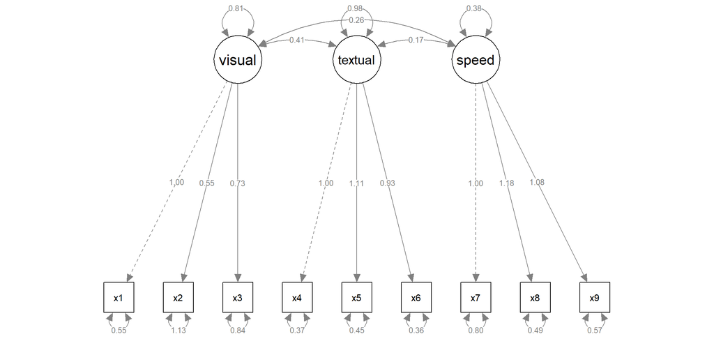

```r
# Plot output
semPaths(cfa_out_1,
         whatLabels = "est",
         nCharNodes = 0,
         nCharEdges = 0)
```

**NOTE:**  
When using the cfa() or sem() functions lavaan…  
…Automatically sets the first indicator coefficient to 1  
…Estimates covariances between latent variables  
…Estimates variances for all latent and observed variables  
…Defaults to a Maximum-Likelihood estimator.

# Structural Equation Model (SEM)

## 1. Walking dog

```r
wd_mod_1 <- "
X =~ x1 + x2
Y =~ x4 + x5
Y ~ X
"
wd_out_1 <- sem(wd_mod_1,
                data = df)
summary(wd_out_1,
        fit.measures = TRUE,
        standardized = TRUE)
```

```
## lavaan 0.6.17 ended normally after 32 iterations
##
##   Estimator                                         ML
##   Optimization method                           NLMINB
##   Number of model parameters                         9
##
##   Number of observations                           301
##
## Model Test User Model:
##
##   Test statistic                                 0.252
##   Degrees of freedom                                 1
##   P-value (Chi-square)                           0.616
##
## Model Test Baseline Model:
##
##   Test statistic                               306.333
##   Degrees of freedom                                 6
##   P-value                                        0.000
##
## User Model versus Baseline Model:
##
##   Comparative Fit Index (CFI)                    1.000
##   Tucker-Lewis Index (TLI)                       1.015
##
## Loglikelihood and Information Criteria:
##
##   Loglikelihood user model (H0)              -1771.622
##   Loglikelihood unrestricted model (H1)      -1771.496
##
##   Akaike (AIC)                                3561.244
##   Bayesian (BIC)                              3594.608
##   Sample-size adjusted Bayesian (SABIC)       3566.065
##
## Root Mean Square Error of Approximation:
##
##   RMSEA                                          0.000
##   90 Percent confidence interval - lower         0.000
##   90 Percent confidence interval - upper         0.121
##   P-value H_0: RMSEA <= 0.050                    0.728
```

[output cut: 19 more lines]

```
##     x5                0.880    0.116    7.571    0.000    0.983    0.763
##
## Regressions:
##                    Estimate  Std.Err  z-value  P(>|z|)   Std.lv  Std.all
##   Y ~
##     X                 0.521    0.181    2.876    0.004    0.459    0.459
##
## Variances:
##                    Estimate  Std.Err  z-value  P(>|z|)   Std.lv  Std.all
##    .x1                0.390    0.325    1.201    0.230    0.390    0.287
##    .x2                1.210    0.114   10.617    0.000    1.210    0.876
##    .x4                0.103    0.153    0.676    0.499    0.103    0.077
##    .x5                0.694    0.131    5.292    0.000    0.694    0.418
##     X                 0.969    0.340    2.849    0.004    1.000    1.000
##    .Y                 0.985    0.192    5.134    0.000    0.789    0.789
```

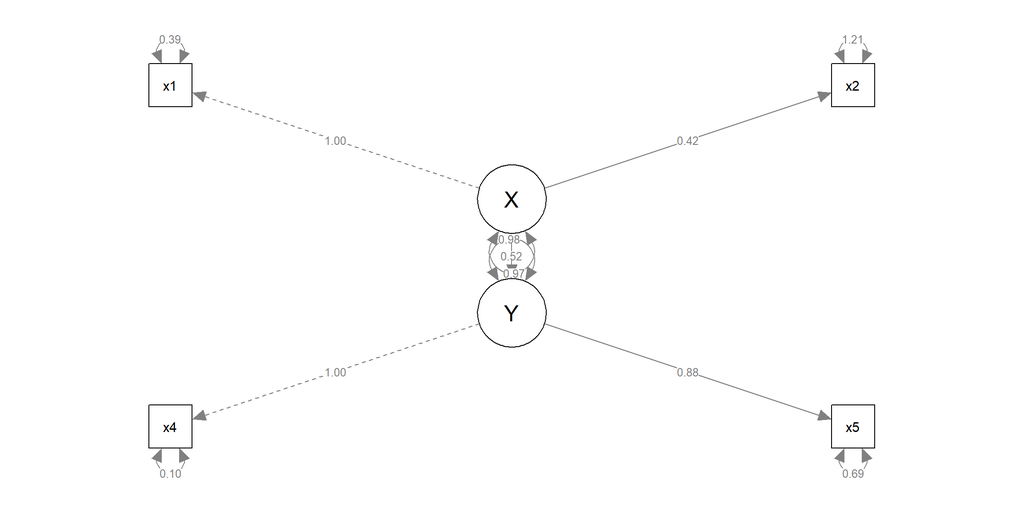

```r
semPaths(wd_out_1,
         whatLabels = "est",
         nCharNodes = 0,
         nCharEdges = 0)
```

## 2. Fix particular coefficients

We can fix particular coefficients to a certain value using pre-multiplication:

```r
### 2.
# we can fix particular coefficients to a certain value using
# pre-multiplication
wd_mod_2 <- "
X =~ 1*x1 + 1*x2
Y =~ 1*x4 + 1*x5
Y ~ X
"
wd_out_2 <- sem(wd_mod_2,
                data =df)
summary(wd_out_2,
        fit.measures = TRUE,
        standardized = TRUE)
```

```
## lavaan 0.6.17 ended normally after 20 iterations
##
##   Estimator                                         ML
##   Optimization method                           NLMINB
##   Number of model parameters                         7
##
##   Number of observations                           301
##
## Model Test User Model:
##
##   Test statistic                                10.819
##   Degrees of freedom                                 3
##   P-value (Chi-square)                           0.013
##
## Model Test Baseline Model:
##
##   Test statistic                               306.333
##   Degrees of freedom                                 6
##   P-value                                        0.000
##
## User Model versus Baseline Model:
##
##   Comparative Fit Index (CFI)                    0.974
##   Tucker-Lewis Index (TLI)                       0.948
##
## Loglikelihood and Information Criteria:
##
##   Loglikelihood user model (H0)              -1776.905
##   Loglikelihood unrestricted model (H1)      -1771.496
##
##   Akaike (AIC)                                3567.811
##   Bayesian (BIC)                              3593.760
##   Sample-size adjusted Bayesian (SABIC)       3571.560
##
## Root Mean Square Error of Approximation:
##
##   RMSEA                                          0.093
##   90 Percent confidence interval - lower         0.038
##   90 Percent confidence interval - upper         0.156
##   P-value H_0: RMSEA <= 0.050                    0.091
```

[output cut: 19 more lines]

```
##     x5                1.000                               1.050    0.811
##
## Regressions:
##                    Estimate  Std.Err  z-value  P(>|z|)   Std.lv  Std.all
##   Y ~
##     X                 0.870    0.181    4.794    0.000    0.533    0.533
##
## Variances:
##                    Estimate  Std.Err  z-value  P(>|z|)   Std.lv  Std.all
##    .x1                0.873    0.101    8.679    0.000    0.873    0.678
##    .x2                1.053    0.111    9.448    0.000    1.053    0.717
##    .x4                0.239    0.059    4.083    0.000    0.239    0.178
##    .x5                0.576    0.072    7.945    0.000    0.576    0.343
##     X                 0.415    0.083    5.014    0.000    1.000    1.000
##    .Y                 0.790    0.115    6.881    0.000    0.716    0.716
```

## 3. Force coefficients

We can force coefficients to have the same value:

```r
wd_mod_3 <- "
X =~ x1 + b1*x2
Y =~ x4 + b1*x5
Y ~ X
"
wd_out_3 <- sem(wd_mod_3,
                data = df)
summary(wd_out_3,
        fit.measures = TRUE,
        standardized = TRUE)
```

```
## lavaan 0.6.17 ended normally after 28 iterations
##
##   Estimator                                         ML
##   Optimization method                           NLMINB
##   Number of model parameters                         9
##   Number of equality constraints                     1
##
##   Number of observations                           301
##
## Model Test User Model:
##
##   Test statistic                                 5.758
##   Degrees of freedom                                 2
##   P-value (Chi-square)                           0.056
##
## Model Test Baseline Model:
##
##   Test statistic                               306.333
##   Degrees of freedom                                 6
##   P-value                                        0.000
##
## User Model versus Baseline Model:
##
##   Comparative Fit Index (CFI)                    0.987
##   Tucker-Lewis Index (TLI)                       0.962
##
## Loglikelihood and Information Criteria:
##
##   Loglikelihood user model (H0)              -1774.375
##   Loglikelihood unrestricted model (H1)      -1771.496
##
##   Akaike (AIC)                                3564.750
##   Bayesian (BIC)                              3594.407
##   Sample-size adjusted Bayesian (SABIC)       3569.036
##
## Root Mean Square Error of Approximation:
##
##   RMSEA                                          0.079
##   90 Percent confidence interval - lower         0.000
##   90 Percent confidence interval - upper         0.158
```

[output cut: 20 more lines]

```
##     x5        (b1)    0.738    0.102    7.202    0.000    0.887    0.698
##
## Regressions:
##                    Estimate  Std.Err  z-value  P(>|z|)   Std.lv  Std.all
##   Y ~
##     X                 0.750    0.166    4.516    0.000    0.478    0.478
##
## Variances:
##                    Estimate  Std.Err  z-value  P(>|z|)   Std.lv  Std.all
##    .x1                0.733    0.128    5.714    0.000    0.733    0.555
##    .x2                1.121    0.110   10.162    0.000    1.121    0.778
##    .x4               -0.100    0.192   -0.521    0.603   -0.100   -0.074
##    .x5                0.830    0.124    6.669    0.000    0.830    0.513
##     X                 0.587    0.133    4.421    0.000    1.000    1.000
##    .Y                 1.116    0.242    4.612    0.000    0.772    0.772
```

## 4.Constrain covariances

We can also constrain covariances to 0. Here we have made the assumption that the visual latent construct is orthogonal to textual and speed (aka has no influence):

```r
wd_mod_4 <- "
visual =~ x1 + x2 + x3
textual =~ x4 + x5 + x6
speed =~ x7 + x8 + x9

visual ~~ 0*textual + 0*speed
"
wd_out_4 <- sem(wd_mod_4,
                data =df)
summary(wd_out_4,
        fit.measures = TRUE,
        standardized = TRUE)
```

```
## lavaan 0.6.17 ended normally after 33 iterations
##
##   Estimator                                         ML
##   Optimization method                           NLMINB
##   Number of model parameters                        19
##
##   Number of observations                           301
##
## Model Test User Model:
##
##   Test statistic                               140.599
##   Degrees of freedom                                26
##   P-value (Chi-square)                           0.000
##
## Model Test Baseline Model:
##
##   Test statistic                               918.852
##   Degrees of freedom                                36
##   P-value                                        0.000
##
## User Model versus Baseline Model:
##
##   Comparative Fit Index (CFI)                    0.870
##   Tucker-Lewis Index (TLI)                       0.820
##
## Loglikelihood and Information Criteria:
##
##   Loglikelihood user model (H0)              -3765.392
##   Loglikelihood unrestricted model (H1)      -3695.092
##
##   Akaike (AIC)                                7568.783
##   Bayesian (BIC)                              7639.218
##   Sample-size adjusted Bayesian (SABIC)       7578.961
##
## Root Mean Square Error of Approximation:
##
##   RMSEA                                          0.121
##   90 Percent confidence interval - lower         0.102
##   90 Percent confidence interval - upper         0.141
##   P-value H_0: RMSEA <= 0.050                    0.000
```

[output cut: 34 more lines]

```
##
## Variances:
##                    Estimate  Std.Err  z-value  P(>|z|)   Std.lv  Std.all
##    .x1                0.835    0.118    7.064    0.000    0.835    0.614
##    .x2                1.065    0.105   10.177    0.000    1.065    0.771
##    .x3                0.633    0.129    4.899    0.000    0.633    0.496
##    .x4                0.382    0.049    7.854    0.000    0.382    0.283
##    .x5                0.418    0.059    7.113    0.000    0.418    0.252
##    .x6                0.367    0.044    8.374    0.000    0.367    0.307
##    .x7                0.729    0.084    8.731    0.000    0.729    0.616
##    .x8                0.422    0.084    5.039    0.000    0.422    0.413
##    .x9                0.665    0.071    9.383    0.000    0.665    0.655
##     visual            0.524    0.130    4.021    0.000    1.000    1.000
##     textual           0.969    0.112    8.647    0.000    1.000    1.000
##     speed             0.454    0.096    4.728    0.000    1.000    1.000
```

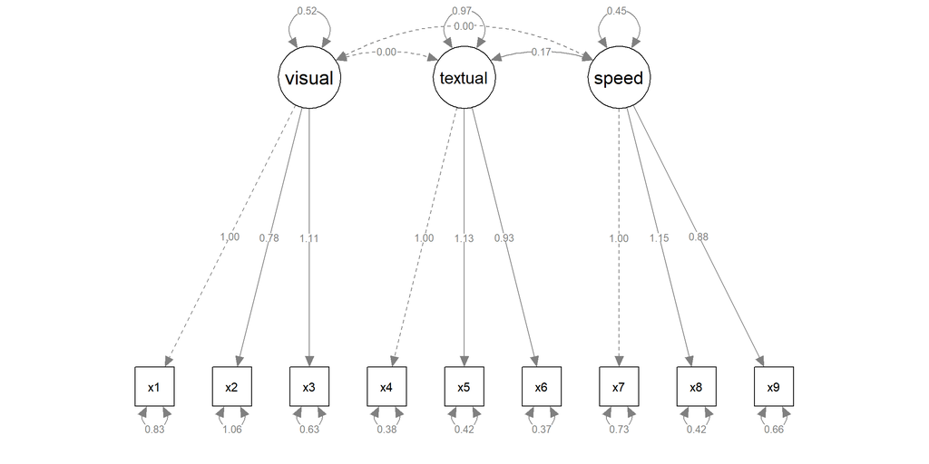

```r
semPaths(wd_out_4,
         whatLabels = "est",
         nCharNodes = 0,
         nCharEdges = 0)
```

## 5. Complex models

We can build complex models (multiple latent variables, regressions and covariances in one model):

```r
complex_mod_1 <- "
# latent variables
visual =~ x1 + x2 + x3
textual =~ x4 + x5 + x6
speed =~ x7 + x8 + x9

# structural model (regressions)
visual ~ textual + speed
textual ~ speed
"
complex_out_1 <- sem(complex_mod_1,
                     data = df)
summary(complex_out_1,
        fit.measures = TRUE,
        standardized = TRUE)
```

```
## lavaan 0.6.17 ended normally after 33 iterations
##
##   Estimator                                         ML
##   Optimization method                           NLMINB
##   Number of model parameters                        21
##
##   Number of observations                           301
##
## Model Test User Model:
##
##   Test statistic                                85.306
##   Degrees of freedom                                24
##   P-value (Chi-square)                           0.000
##
## Model Test Baseline Model:
##
##   Test statistic                               918.852
##   Degrees of freedom                                36
##   P-value                                        0.000
##
## User Model versus Baseline Model:
##
##   Comparative Fit Index (CFI)                    0.931
##   Tucker-Lewis Index (TLI)                       0.896
##
## Loglikelihood and Information Criteria:
##
##   Loglikelihood user model (H0)              -3737.745
##   Loglikelihood unrestricted model (H1)      -3695.092
##
##   Akaike (AIC)                                7517.490
##   Bayesian (BIC)                              7595.339
##   Sample-size adjusted Bayesian (SABIC)       7528.739
##
## Root Mean Square Error of Approximation:
##
##   RMSEA                                          0.092
##   90 Percent confidence interval - lower         0.071
##   90 Percent confidence interval - upper         0.114
##   P-value H_0: RMSEA <= 0.050                    0.001
```

[output cut: 34 more lines]

```
##
## Variances:
##                    Estimate  Std.Err  z-value  P(>|z|)   Std.lv  Std.all
##    .x1                0.549    0.114    4.833    0.000    0.549    0.404
##    .x2                1.134    0.102   11.146    0.000    1.134    0.821
##    .x3                0.844    0.091    9.317    0.000    0.844    0.662
##    .x4                0.371    0.048    7.778    0.000    0.371    0.275
##    .x5                0.446    0.058    7.642    0.000    0.446    0.269
##    .x6                0.356    0.043    8.277    0.000    0.356    0.298
##    .x7                0.799    0.081    9.823    0.000    0.799    0.676
##    .x8                0.488    0.074    6.573    0.000    0.488    0.477
##    .x9                0.566    0.071    8.003    0.000    0.566    0.558
##    .visual            0.537    0.117    4.582    0.000    0.664    0.664
##    .textual           0.901    0.106    8.496    0.000    0.920    0.920
##     speed             0.384    0.086    4.451    0.000    1.000    1.000
```

```r
parameterestimates(complex_out_1)
```

```
##        lhs op     rhs   est    se      z pvalue ci.lower ci.upper
## 1   visual =~      x1 1.000 0.000     NA     NA    1.000    1.000
## 2   visual =~      x2 0.554 0.100  5.554      0    0.358    0.749
## 3   visual =~      x3 0.729 0.109  6.685      0    0.516    0.943
## 4  textual =~      x4 1.000 0.000     NA     NA    1.000    1.000
## 5  textual =~      x5 1.113 0.065 17.014      0    0.985    1.241
## 6  textual =~      x6 0.926 0.055 16.703      0    0.817    1.035
## 7    speed =~      x7 1.000 0.000     NA     NA    1.000    1.000
## 8    speed =~      x8 1.180 0.165  7.152      0    0.857    1.503
## 9    speed =~      x9 1.082 0.151  7.155      0    0.785    1.378
## 10  visual  ~ textual 0.321 0.067  4.776      0    0.190    0.453
## 11  visual  ~   speed 0.538 0.130  4.152      0    0.284    0.792
## 12 textual  ~   speed 0.452 0.124  3.654      0    0.210    0.695
## 13      x1 ~~      x1 0.549 0.114  4.833      0    0.326    0.772
## 14      x2 ~~      x2 1.134 0.102 11.146      0    0.934    1.333
## 15      x3 ~~      x3 0.844 0.091  9.317      0    0.667    1.022
## 16      x4 ~~      x4 0.371 0.048  7.778      0    0.278    0.465
## 17      x5 ~~      x5 0.446 0.058  7.642      0    0.332    0.561
## 18      x6 ~~      x6 0.356 0.043  8.277      0    0.272    0.441
## 19      x7 ~~      x7 0.799 0.081  9.823      0    0.640    0.959
## 20      x8 ~~      x8 0.488 0.074  6.573      0    0.342    0.633
## 21      x9 ~~      x9 0.566 0.071  8.003      0    0.427    0.705
## 22  visual ~~  visual 0.537 0.117  4.582      0    0.307    0.767
## 23 textual ~~ textual 0.901 0.106  8.496      0    0.693    1.109
## 24   speed ~~   speed 0.384 0.086  4.451      0    0.215    0.553
```

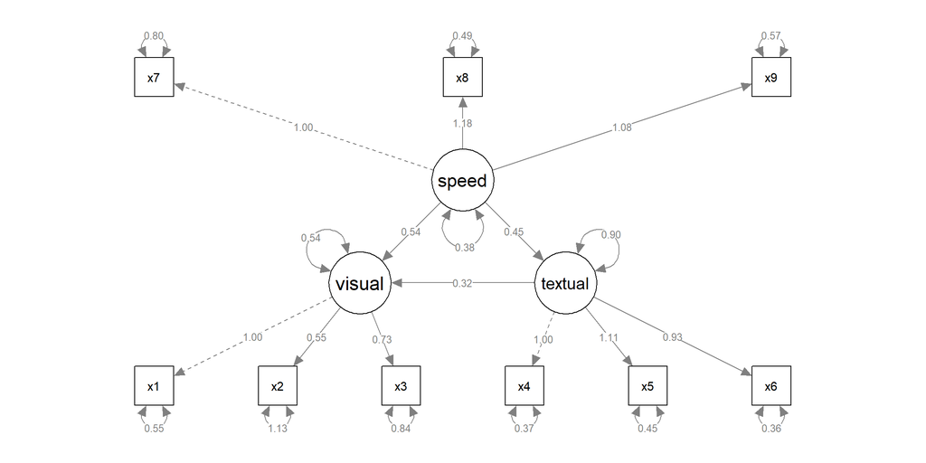

```r
semPaths(complex_out_1,
         whatLabels = "est",
         nCharNodes = 0,
         nCharEdges = 0)
```

## 6. Improve model fit

The following measures are use to judge the model fit:  
- Did lavaan end normally?  
**Global fit**  
- Model Test User Model: p-value (Chi-square) should not be significant (>= 0.05)  
- CFI should be >= 0.95  
- RMSEA should be <= 0.06 (additionally the p-value for RMSEA <= 0.05 should not be significant (>= 0.05))  
- SRMR should be <= 0.08  
**Local fit**  
The lavaan package can give us suggestions for improving the local model fit:

```r
modindices(complex_out_1) %>%
  # chose a threshold (10 is recommended). The higher the
  # mi-value the bigger the (potential) improvement regarding
  # the model fit.
  # NOTE: are the recommendations theoretically meaningful?
  filter(mi > 10)
```

```
##      lhs op rhs     mi    epc sepc.lv sepc.all sepc.nox
## 1 visual =~  x7 18.631 -0.422  -0.380   -0.349   -0.349
## 2 visual =~  x9 36.411  0.577   0.519    0.515    0.515
## 3     x7 ~~  x8 34.145  0.536   0.536    0.859    0.859
## 4     x8 ~~  x9 14.946 -0.423  -0.423   -0.805   -0.805
```

**Furthermore:**  
- Variances should be >= 0.  
- Factor-Loadings for the latent variables (“Std.all”) should be high enough (>= 0.6/0.7)

Include the suggested covariance (x7 ~~ x8):

```r
complex_mod_2 <- "
# latent variables
visual =~ x1 + x2 + x3
textual =~ x4 + x5 + x6
speed =~ x7 + x8 + x9

# structural model (what is the relationship between the latent variables? Regressions)
visual ~ textual + speed
textual ~ speed

# covariances
x7 ~~ x8
"
complex_out_2 <- sem(complex_mod_2,
                     data = df)
summary(complex_out_2,
        fit.measures = TRUE,
        standardized = TRUE)
```

```
## lavaan 0.6.17 ended normally after 40 iterations
##
##   Estimator                                         ML
##   Optimization method                           NLMINB
##   Number of model parameters                        22
##
##   Number of observations                           301
##
## Model Test User Model:
##
##   Test statistic                                53.272
##   Degrees of freedom                                23
##   P-value (Chi-square)                           0.000
##
## Model Test Baseline Model:
##
##   Test statistic                               918.852
##   Degrees of freedom                                36
##   P-value                                        0.000
##
## User Model versus Baseline Model:
##
##   Comparative Fit Index (CFI)                    0.966
##   Tucker-Lewis Index (TLI)                       0.946
##
## Loglikelihood and Information Criteria:
##
##   Loglikelihood user model (H0)              -3721.728
##   Loglikelihood unrestricted model (H1)      -3695.092
##
##   Akaike (AIC)                                7487.457
##   Bayesian (BIC)                              7569.013
##   Sample-size adjusted Bayesian (SABIC)       7499.242
##
## Root Mean Square Error of Approximation:
##
##   RMSEA                                          0.066
##   90 Percent confidence interval - lower         0.043
##   90 Percent confidence interval - upper         0.090
##   P-value H_0: RMSEA <= 0.050                    0.118
```

[output cut: 39 more lines]

```
##
## Variances:
##                    Estimate  Std.Err  z-value  P(>|z|)   Std.lv  Std.all
##    .x1                0.576    0.101    5.678    0.000    0.576    0.424
##    .x2                1.122    0.100   11.171    0.000    1.122    0.812
##    .x3                0.832    0.087    9.552    0.000    0.832    0.653
##    .x4                0.372    0.048    7.791    0.000    0.372    0.276
##    .x5                0.444    0.058    7.600    0.000    0.444    0.267
##    .x6                0.357    0.043    8.287    0.000    0.357    0.298
##    .x7                1.036    0.090   11.501    0.000    1.036    0.876
##    .x8                0.795    0.080    9.988    0.000    0.795    0.778
##    .x9                0.088    0.188    0.466    0.641    0.088    0.086
##    .visual            0.470    0.105    4.479    0.000    0.600    0.600
##    .textual           0.907    0.106    8.569    0.000    0.927    0.927
##     speed             0.147    0.056    2.615    0.009    1.000    1.000
```

The model fit did improve. But is it a significant improvement? Yes!

```r
lavTestLRT(complex_out_1, complex_out_2)
```

```
##
## Chi-Squared Difference Test
##
##               Df    AIC    BIC  Chisq Chisq diff   RMSEA Df diff Pr(>Chisq)
## complex_out_2 23 7487.5 7569.0 53.272
## complex_out_1 24 7517.5 7595.3 85.305     32.033 0.32109       1  1.516e-08 ***
## ---
## Signif. codes:  0 '***' 0.001 '**' 0.01 '*' 0.05 '.' 0.1 ' ' 1
```

## 7. Alternate estimaors

lavaan defaults to using a full-information Maximum-Likelihood (ML) Estimator. This is the most efficient estimator available and can handle missing data (missing=ml). We may want to specify alternate estimators if our data do not meet the assumptions for ML. By adding the estimator= argument to our cfa(), sem(), or lavaan() call, we can choose another estimator.  
**Some useful choices:**  
**estimator=“MLM”:** ML with robust errors and Satorra-Bentler test statistic.  
**estimator=“WLSMV”:** Weighted least squares with mean and variance adjusted test statistic (needed for categorical endogenous variables).

## 8. Categorical variables

If you provide lavaan categorical data as an endogenous variable, it will automatically use a proper estimator (e.g. Diagonally Weighted Least Squares). To specify an ordinal variable as categorical, you will want to make it an ordered factor:

```r
iris %>%
  as_tibble() %>%
  mutate(Species = ordered(Species)) %>%
  glimpse()
```

```
## Rows: 150
## Columns: 5
## $ Sepal.Length <dbl> 5.1, 4.9, 4.7, 4.6, 5.0, 5.4, 4.6, 5.0, 4.4, 4.9, 5.4, 4.…
## $ Sepal.Width  <dbl> 3.5, 3.0, 3.2, 3.1, 3.6, 3.9, 3.4, 3.4, 2.9, 3.1, 3.7, 3.…
## $ Petal.Length <dbl> 1.4, 1.4, 1.3, 1.5, 1.4, 1.7, 1.4, 1.5, 1.4, 1.5, 1.5, 1.…
## $ Petal.Width  <dbl> 0.2, 0.2, 0.2, 0.2, 0.2, 0.4, 0.3, 0.2, 0.2, 0.1, 0.2, 0.…
## $ Species      <ord> setosa, setosa, setosa, setosa, setosa, setosa, setosa, s…
```

Unordered categorical variables (factors) will need to be split into dummy variables prior to estimation:

```r
iris %>%
  fastDummies::dummy_cols(select_columns = "Species",
                          remove_first_dummy = TRUE,
                          remove_selected_columns = TRUE) %>%
  glimpse()
```

```
## Rows: 150
## Columns: 6
## $ Sepal.Length       <dbl> 5.1, 4.9, 4.7, 4.6, 5.0, 5.4, 4.6, 5.0, 4.4, 4.9, 5…
## $ Sepal.Width        <dbl> 3.5, 3.0, 3.2, 3.1, 3.6, 3.9, 3.4, 3.4, 2.9, 3.1, 3…
## $ Petal.Length       <dbl> 1.4, 1.4, 1.3, 1.5, 1.4, 1.7, 1.4, 1.5, 1.4, 1.5, 1…
## $ Petal.Width        <dbl> 0.2, 0.2, 0.2, 0.2, 0.2, 0.4, 0.3, 0.2, 0.2, 0.1, 0…
## $ Species_versicolor <int> 0, 0, 0, 0, 0, 0, 0, 0, 0, 0, 0, 0, 0, 0, 0, 0, 0, …
## $ Species_virginica  <int> 0, 0, 0, 0, 0, 0, 0, 0, 0, 0, 0, 0, 0, 0, 0, 0, 0, …
```